# Data Visualization with Significant Stars

Oluwafemi Oyedele

2/23/2022

# As a scientist you have to report on your findings at conferences from time to time. Your audience expects to be informed about your main findings, at best through a simple visualization that depicts these findings. Usually, statistical tests examine group differences, which can be depicted as barcharts. Statistical significance tests are usually represented in these barcharts with horizontal lines on which the p-values are displayed. Therefore, in this tutorial, you will create a custom barchart from a dataset of the sleep duration of different animals.

# Getting and wrangling the data

# We will work with a datset that is already inclueded in the ggplot2 package. The dataset is called msleep and includes the sleep duration of mammals. Let’s first load our packages and look at the data:

# Since we are interested in the sleep duration of different animals, our variables of interest are vore and sleep_total. First, we need to refactor the data so that we have the mean sleep duration of these animals and the standard deviation of the sleep duration:

```
## # A tibble: 5 x 3
##   vore    mean_sleep sd_sleep
##   <chr>        <dbl>    <dbl>
## 1 carni        10.4      4.67
## 2 herbi         9.51     4.88
## 3 insecti      14.9      5.92
## 4 omni         10.9      2.95
## 5 <NA>         10.2      3.00
```

# To obtain this data, we first grouped the data with group_by and then calculated the summary statistics with summarise.

But the data is not yet perfect. We have missing values in the dataset and the animal names are abbreviated. Let’s solve these problems:

```
## # A tibble: 4 x 3
##   vore        mean_sleep sd_sleep
##   <fct>            <dbl>    <dbl>
## 1 carnivore        10.4      4.67
## 2 herbivore         9.51     4.88
## 3 insectivore      14.9      5.92
## 4 omnivore         10.9      2.95
```

# First, we change the names of the vore variable with the function case_when. Before the tilde ~ we specify the match of a certain case (here the respective string), to the right of the tilde we specify the new value. Second, we convert the variable vore into a factor. We need to do this because the factor allows us the define the order in which the barplots are displayed in the visualization. Hence, we use the function fct_relevel to make sure the insectivores come first, then the omnivores, then the carnivores and last the herbivores. We choose this order because it corresponds to the mean differences of the animals. Finally, we use the function drop_na to get rid of the NA value.

# Creating the first barchart

Now we are in place to create the first barchart:

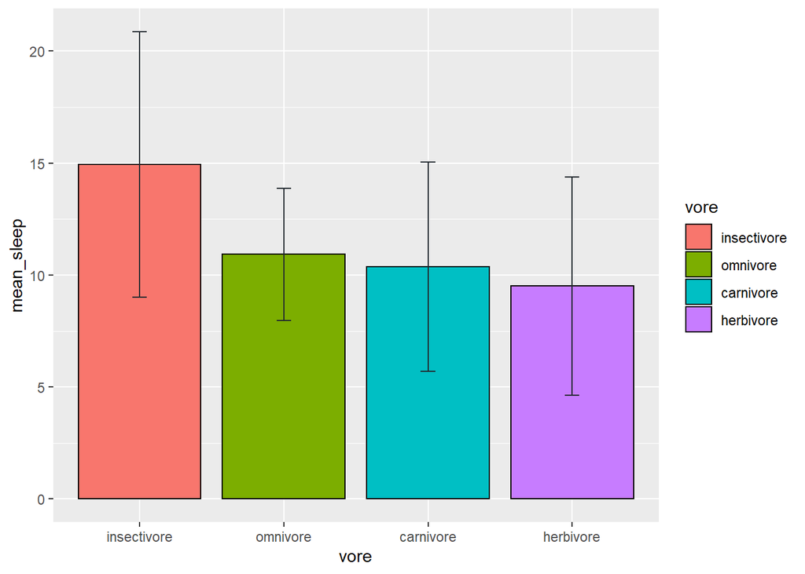

# The visualization is a good first step, but there are still some problems. For example, the legend is redundant. We already know that the red barplot depicts insectivores. Also, the x and y values are not really meaningful. We need to rename them and make them more meaningful. And we do not have a title or caption to tell our readers what the error bars mean. Another problem is that the colors of the barchart might be misleading. Why should insectivores be red? Let’s apply these changes in the next visualization: